# Introduction

`bubblyr` is an R wrapper of the JavaScript library bubbly-bg. It allows you to add beautiful animated bubbles within Shiny and RMarkdown backgrounds. You can choose from several themes and apply the animation with one line of code.

## Installation

You can install the `bubblyr` package from CRAN with:

```r
install.packages("bubblyr")
```

You can install the development version of `bubblyr` from Github with:

```r
install.packages("remotes") #if not installed

remotes::install_github("feddelegrand7/bubblyr")
```

# Themes

Here a list of all the available themes. Note that The ocean, cherry, hippie, bigmom and deepsea themes are provided by the author of the bubbly-bg library, I just gave them some fancy names:

| Themes |
| --- |
| ocean |
| cherry |
| hippie |
| bigmom |
| deepsea |
| illusion |
| rstudio |
| ash |
| classy |
| volcano |
| lacoste |
| warmup |
| fire |
| traffic |
| life |
| darksky |
| orangina |
| meteor |
| gravitas |
| rladies |
| sunshine |
| sweet |
| lalaland |

Below you can find some examples, feel free to experiment the remaining themes:

#### Important: You may experiment some lags if you view your Shiny app in RStudio, instead experiment the themes in the browser.

```r
library(shiny)
library(bubblyr)

ui <- fluidPage(

    bubbly(theme = "bigmom")

)

server <- function(input, output) {}

shinyApp(ui = ui, server = server)
```

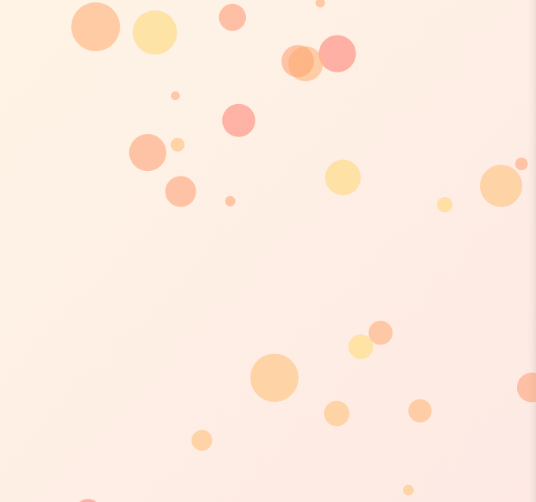

```r
library(shiny)
library(bubblyr)

ui <- fluidPage(

    bubbly(theme = "rstudio")

)

server <- function(input, output) {}

shinyApp(ui = ui, server = server)
```

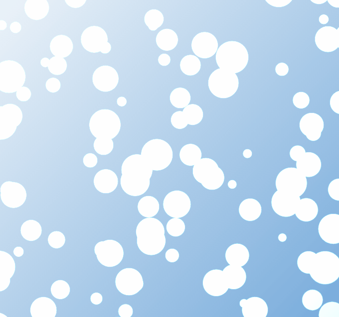

```r
library(shiny)
library(bubblyr)

ui <- fluidPage(

    bubbly(theme = "classy")

)

server <- function(input, output) {}

shinyApp(ui = ui, server = server)
```

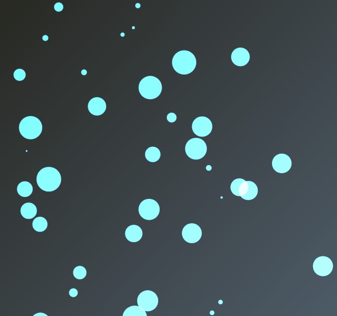

## Code of Conduct

Please note that the bubblyr project is released with a [Contributor Code of Conduct](https://contributor-covenant.org/version/2/0/CODE_OF_CONDUCT.html). By contributing to this project, you agree to abide by its terms.